# Script_2-Figura_2

Maximiliano León

07-11-2021

```r
## Importamos datos
## (Usando el mismo metodo anterior, el metodo visto en clases para llamar la variable arroja error)
datos <- rio::import(here::here("Datos Iniciales/vgsales.csv"))
promedio_anual_por_genero <- sqldf("select Genre, Year, sum(Global_Sales) as Ventas from datos group by Genre, Year")

DT2 <- promedio_anual_por_genero[-which(promedio_anual_por_genero$Year == "N/A"),]


#Nuevo
#Hacemos numerica la variable año(Year), ya que no lo era
DT2$Year <- as.numeric(DT2$Year)

#Eliminamos datos poco favorables para estudio
DT2 <- DT2[-which(DT2$Year == 2020),]
DT2 <- DT2[-which(DT2$Year == 2017),]
DT2 <- DT2[-which(DT2$Year == 2016),]
```

Finalmente, con la base de datos abarcando desde 1980 a 2015, haremos algunos graficos de exploracion para tener ideas generales sobre los datos, y luego otros mas concluyentes.

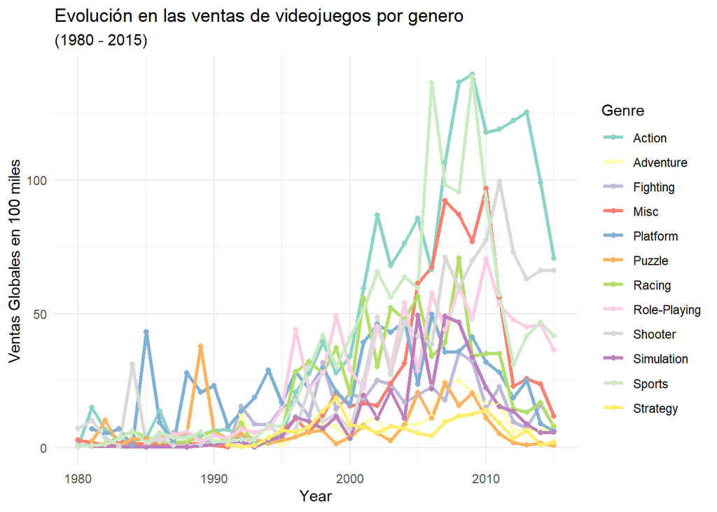

```r
ggplot(DT2, aes(x = Year, y = Ventas, color = Genre)) +
  geom_line(size = 1.1) +
  theme_minimal() +
  labs(title = "Evolución en las ventas de videojuegos por genero",
       subtitle = "(1980 - 2015)",
       y = "Ventas Globales en 100 miles",
       x = "Year") +
  geom_point(size = 1.5) +
  scale_color_brewer(palette = "Set3")
```

```r
ggsave( device = "png", filename = "evolucion_ventas_videojuegos_por_genero_v2", path = here::here("Figuras"))
```

Tambien es importante notar que aproximadamente en el 2013, hay una baja importante en la mayoria de los videojuegos, este hecho calza con la salida de League of legends en 2011, que tuvo un exito explosivo en los años siguientes, (este no se encuentra representado dentro de la tabla dado que es un juego gratis).

Si bien no presenta ventas tan altas, es destacable el peak de 1984 de los shooter, con “Duck Hunt” como el mas vendido, y posteriormente el peak de 1985 en juegos de plataformas, este exito es basicamente gracias a las ventas de “Super Mario Bros.”, por lo que podriamos hablar de que estos juegos son un gran catapultante al exito de los juegos de hoy en día.